# Extended War Report

2026-04-13

# Overview

This is an extended war report for the war **39491** between **Shadow Reapers** and **Torn Community Garden**. Data is presented from the side of **Torn Community Garden**. Link to the official war report can be found [HERE](https://www.torn.com/war.php?step=rankreport&rankID=39491).

## Rewards

War outcome for your faction: **Victory**  
Total hits done: **1409**  
War hits: **1169**  
Non war hits: **240**  
Total respect earned: **12904.06**  
Members contributed: **50/64**

Rewards for your faction:

| Name | Amount | Price |
| --- | --- | --- |
| Medium Arms Cache | 3 | 677.48 M |
| Melee Cache | 3 | 499.27 M |
| Armor Cache | 4 | 1.32 B |

Earnings from caches: **2.5 B**  
Total earnings: **2.5 B**<sup>1</sup>

<sup>1</sup>prices are based on market value or approximate trader prices if market value is unavaliable.

## War Preparation

**NOTE**: Faction Xanax might be different from Prep Xanax due to how personal stats are calculated. In this case, Faction Xanax is more accurate.

Members who **did not stack** energy before war:

|  | Name | Prep_Xanax | Faction_Xanax | Total_Hits |
| --- | --- | --- | --- | --- |
| 1 | -Antheia- | 2 |  | 17 |
| 2 | Alan_Wake | 2 |  | 5 |
| 3 | Anthrax132 | 3 |  | 40 |
| 4 | Brandy13 | 2 |  | 31 |
| 5 | Buzzsmo | 3 |  | 2 |
| 6 | Captain_Chimkin | 1 |  | 5 |
| 7 | Chapelle | 3 | 1 | 9 |
| 8 | EXIGULAE | 0 |  | 2 |
| 9 | FogBorne | 3 | 3 | 6 |
| 10 | Ganjah | 1 |  | 0 |

[output cut: 16 more lines]

Members who **overdosed** during war preparations (but could still have stacked):

|  | Name | Prep_Xanax | Faction_Xanax | Total_Hits |
| --- | --- | --- | --- | --- |
| 1 | Happymeal | 4 | 1 | 1 |
| 2 | Sottom | 4 | 4 | 8 |
| 3 | mlem | 5 | 4 | 42 |

Members who **most likely stacked** energy before war (or just used lots of xanax):

|  | Name | Prep_Xanax | Faction_Xanax | Total_Hits |
| --- | --- | --- | --- | --- |
| 1 | Alchemist-Ifrit | 4 | 5 | 38 |
| 2 | BakedBeanSoup | 6 | 4 | 51 |
| 3 | BarkingPupGirl | 5 | 5 | 4 |
| 4 | BillTheImpaler | 5 | 4 | 48 |
| 5 | BlackLab | 7 | 3 | 34 |
| 6 | Brenadryl | 4 | 4 | 53 |
| 7 | Bucknutz | 5 | 4 | 49 |
| 8 | Ch3wie | 4 |  | 45 |
| 9 | D3adpool | 4 | 4 | 33 |
| 10 | Darnclip | 5 | 3 | 6 |

[output cut: 25 more lines]

## Fighting summary

### Top 5

Top 5 by overall contribution %

| Name | Contribution |
| --- | --- |
| miel | 6.53 |
| cutt | 4.83 |
| Nordy14740 | 4.68 |
| Supreme_ | 4.05 |
| Karlach_Punk | 3.97 |

Top 5 by War hits

| Name | War_Hits |
| --- | --- |
| miel | 92 |
| cutt | 68 |
| Nordy14740 | 66 |
| Karlach_Punk | 56 |
| Harleequiin | 53 |

Top 5 by Non War hits

| Name | Non_War_Hits |
| --- | --- |
| BakedBeanSoup | 51 |
| Zoot | 37 |
| ScatterBean | 36 |
| FalconCY | 36 |
| Supreme_ | 35 |

Top 5 by Total hits

| Name | Total_Hits |
| --- | --- |
| miel | 92 |
| cutt | 68 |
| Nordy14740 | 66 |
| Supreme_ | 57 |
| Karlach_Punk | 56 |

Top 5 by Assists

| Name | Assists |
| --- | --- |
| Supreme_ | 7 |
| BlackLab | 4 |
| HowietzerH | 2 |
| Brandy13 | 2 |
| Nordy14740 | 2 |

Chain savers - List of people who saved the chain with less than 60 seconds remaining.

```
## [1] "No friendly chain saves found!"
```

```
## [1] "No enemy chain saves found!"
```

### Visual summary

Only including members with non-zero contribution

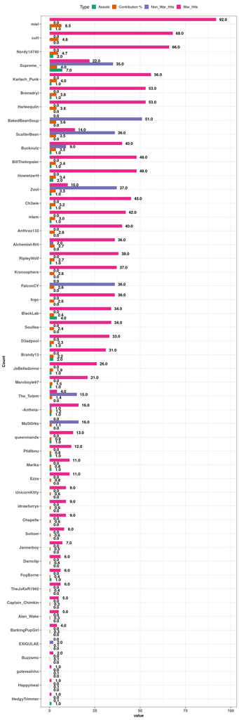

### Respect

Respect earned by each member.<sup>1</sup>  
Total respect earned: **12904.06**  
Total respect lost: **862.46**  
Net respect change: **12041.6**<sup>2</sup>  
Average respect earned per attack: **8.26**

<sup>1</sup>Chain bonuses are ignored in per-member contributions.  
<sup>2</sup>Respect lost will be 0 if using non-faction API key.

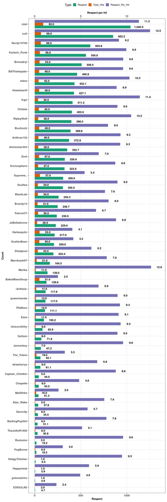

### War Score

Looking at war score gained and lost by each member.  
**The calculations IGNORE chain bonuses in order to better reflect actual contribution rather than landing a lucky hit**  
Total score earned: **10665.59**  
Total score lost: **3095.89**<sup>1</sup>  
Median net score per member: **44.37**<sup>2</sup>

<sup>1</sup>Score lost will be 0 if using non-faction API key.  
<sup>2</sup>Using median instead of mean to avoid extreme values skewing the metric.

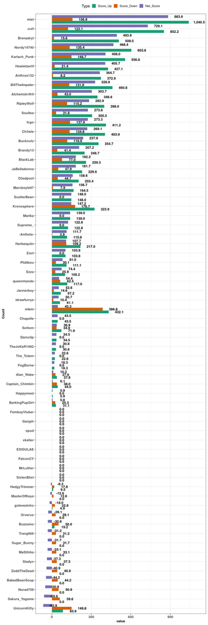

### Slackers

Members who did not meet 1% contribution cutoff

| Name | Contribution |
| --- | --- |
| queenmands | 0.92 |
| Ptidibou | 0.85 |
| Ezza | 0.78 |
| Marika | 0.78 |
| Chapelle | 0.64 |
| idrawfurrys | 0.64 |
| UnicornKitty | 0.64 |
| Sottom | 0.57 |
| Jannerboy | 0.50 |
| TheJoKeR1992 | 0.43 |
| FogBorne | 0.43 |
| Darnclip | 0.43 |
| Alan_Wake | 0.35 |
| Captain_Chimkin | 0.35 |
| BarkingPupGirl | 0.28 |
| Buzzsmo | 0.14 |
| EXIGULAE | 0.14 |
| HedgyTrimmer | 0.07 |
| Happymeal | 0.07 |
| golevezinho | 0.07 |
| SixtenBlixt | 0.00 |
| MrLuther | 0.00 |
| Orverus | 0.00 |
| MasterOfKeys | 0.00 |
| Sladyn | 0.00 |
| Sakura_Yagame | 0.00 |
| Trang666 | 0.00 |
| ZeddTheDead | 0.00 |
| xkatier | 0.00 |
| spud | 0.00 |
| Norad758 | 0.00 |
| Sugar_Bunny | 0.00 |
| Ganjah | 0.00 |
| FemboyVtuber | 0.00 |

### Energy

Summary of who wasted the most energy and who cost the enemy the most energy.  
Calculated by adding up Losses (and Stalemates, Defends, Escapes, Interrupts) and Defends, the multiplying the number by 25.  
E_Wasted means the member spent X energy on attacks that failed.  
E_Stolen means X energy was wasted by the enemy on attacking the member unsuccessfully.  
You might want to take a closer look at members with high E_Wasted values and remind them to pick fights they can win!

<sup>1</sup> These numbers will be 0 if you are using an API key WITHOUT faction access.

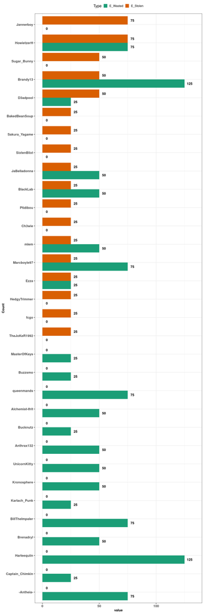

### Full table

Full table with filters and search

|  | Name | Total_Hits | Contribution | War_Hits | Non_War_Hits | Assists | Respect | Respect_Per_Hit | Respect_Lost | Score_Up | Score_Down | Net_Score |
| --- | --- | --- | --- | --- | --- | --- | --- | --- | --- | --- | --- | --- |
| 1 | TheJoKeR1992 | 6 | 0.43 | 6 | 0 | 0 | 30.83000000000001 | 5.14 | 0 | 30.83000000000001 | 0 | 30.83 |
| 2 | fcgo | 36 | 2.56 | 36 | 0 | 0 | 411.1799999999999 | 11.42 | 34.49 | 411.1799999999999 | 137.92 | 273.26 |
| 3 | HedgyTrimmer | 1 | 0.07 | 1 | 0 | 1 | 9.48 | 9.48 | 4.46 | 9.48 | 17.8 | -8.32 |
| 4 | Ezza | 11 | 0.78 | 11 | 0 | 0 | 100.25 | 9.11 | 6.470000000000001 | 100.25 | 25.86 | 74.39 |
| 5 | Zoot | 47 | 3.34 | 10 | 37 | 1 | 326.8799999999999 | 6.95 | 0 | 103.77 | 0 | 103.77 |
| 6 | The_Totem | 19 | 1.35 | 4 | 15 | 0 | 62.06999999999999 | 3.27 | 0 | 22.55 | 0 | 22.55 |
| 7 | Happymeal | 1 | 0.07 | 1 | 0 | 0 | 5.9 | 5.9 | 0 | 5.9 | 0 | 5.9 |
| 8 | Alan_Wake | 5 | 0.35 | 5 | 0 | 0 | 37.8 | 7.56 | 6.9 | 37.8 | 27.61 | 10.19 |
| 9 | Marika | 11 | 0.78 | 11 | 0 | 1 | 139.04 | 12.64 | 0 | 139.04 | 0 | 139.04 |
| 10 | BarkingPupGirl | 4 | 0.28 | 4 | 0 | 0 | 31.15 | 7.79 | 6.319999999999999 | 31.15 | 25.32 | 5.83 |

[output cut: 54 more lines]

## Extra details

### Xanax and refill usage

Xanax and Energy refill usage during the war.

Total Xanax used: **140**  
Xanax costs: **123.87 M**  
Total Refills used: **98**  
Refill costs: **83.42 M**

Drug cost in plot is in millions.

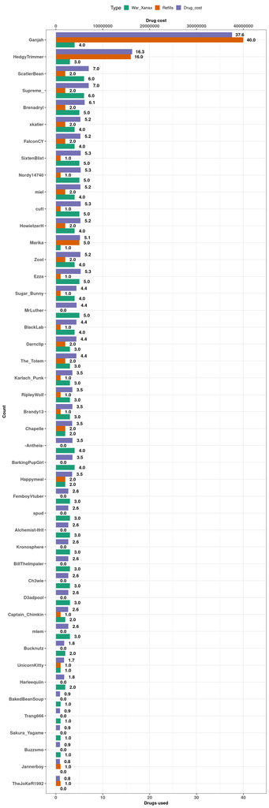

### Booster and can usage

Energy can and Booster usage during the war.

Total Boosters used: **45**  
Booster costs: **554.75 M**  
Total Cans used: **14**  
Can costs: **23.62 M**

All Boosters are assumed to be FHCs and Can price is set to average market value for ALL cans.

Booster cost in plot is in 10s of millions.

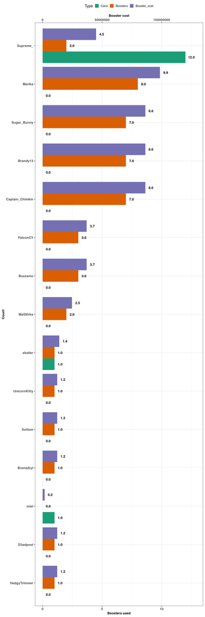

### Armory usage (BETA)

This is a summary of Armory usage during the preparation and war period.  
It can be useful for getting a good idea of how much consumables were used during the war in total.

<sup>1</sup> This section will be empty if you are using an API key WITHOUT faction access.

#### During preparation

```
## [1] "Preparation Armory usage:"
```

|  | Name | ID | action | amount | item | Hours_to_war |
| --- | --- | --- | --- | --- | --- | --- |
| 1 | Sakura_Yagame | 4101395 | loaned | 1 | ID Badge | 71.6 |
| 2 | Sakura_Yagame | 4101395 | loaned | 1 | Enfield SA-80 | 71.58 |
| 3 | MaSt0rks | 4184136 | used | 1 | Ipecac Syrup | 71.56 |
| 4 | cutt | 2944902 | used | 1 | Xanax | 70.89 |
| 5 | ScatterBean | 3383329 | used | 1 | Bottle of Beer | 70.84 |
| 6 | ScatterBean | 3383329 | used | 1 | Xanax | 70.54 |
| 7 | Buzzsmo | 4166987 | used | 1 | First Aid Kit | 69.95 |
| 8 | Buzzsmo | 4166987 | used | 1 | First Aid Kit | 69.95 |
| 9 | Buzzsmo | 4166987 | used | 1 | First Aid Kit | 69.95 |
| 10 | Buzzsmo | 4166987 | used | 1 | First Aid Kit | 69.95 |

[output cut: 776 more lines]

```
## [1] "Preparation usage totals:"
```

|  | Action | Item | Count |
| --- | --- | --- | --- |
| 1 | used | Bottle of Beer | 422 |
| 2 | used | Xanax | 156 |
| 3 | used | Bag of Chocolate Kisses | 83 |
| 4 | loaned | Smoke Grenade | 35 |
| 5 | used | Morphine | 32 |
| 6 | used | Blood Bag : A+ | 24 |
| 7 | used | First Aid Kit | 20 |
| 8 | used | Blood Bag : B- | 9 |
| 9 | loaned | Tear Gas | 7 |
| 10 | used | Cannabis | 6 |

[output cut: 26 more lines]

```
## [1] "Only showing consumables"
```

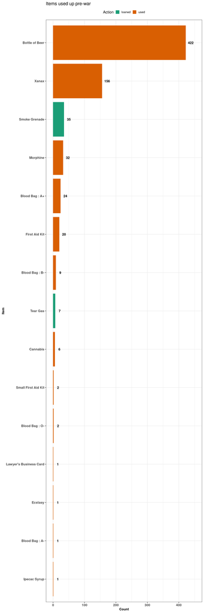

#### During war

```
## [1] "War Armory usage:"
```

|  | Name | ID | action | amount | item | Hours_to_end |
| --- | --- | --- | --- | --- | --- | --- |
| 1 | mlem | 2729522 | used | 1 | Blood Bag : O+ | 6.76 |
| 2 | cutt | 2944902 | used | 1 | First Aid Kit | 6.74 |
| 3 | cutt | 2944902 | used | 1 | First Aid Kit | 6.74 |
| 4 | cutt | 2944902 | used | 1 | First Aid Kit | 6.74 |
| 5 | BillTheImpaler | 3683008 | used | 1 | First Aid Kit | 6.73 |
| 6 | BillTheImpaler | 3683008 | used | 1 | First Aid Kit | 6.73 |
| 7 | BlackLab | 4012506 | used | 1 | Blood Bag : A+ | 6.73 |
| 8 | cutt | 2944902 | used | 1 | First Aid Kit | 6.73 |
| 9 | cutt | 2944902 | used | 1 | First Aid Kit | 6.73 |
| 10 | cutt | 2944902 | used | 1 | First Aid Kit | 6.73 |

[output cut: 437 more lines]

```
## [1] "War usage totals:"
```

|  | Action | Item | Count |
| --- | --- | --- | --- |
| 1 | loaned | Flash Grenade | 200 |
| 2 | used | Small First Aid Kit | 127 |
| 3 | used | First Aid Kit | 120 |
| 4 | used | Blood Bag : A+ | 53 |
| 5 | loaned | Tear Gas | 37 |
| 6 | used | Blood Bag : O+ | 22 |
| 7 | used | Blood Bag : O- | 21 |
| 8 | used | Blood Bag : B- | 20 |
| 9 | used | Blood Bag : A- | 18 |
| 10 | used | Morphine | 17 |

[output cut: 8 more lines]

```
## [1] "Only showing consumables"
```

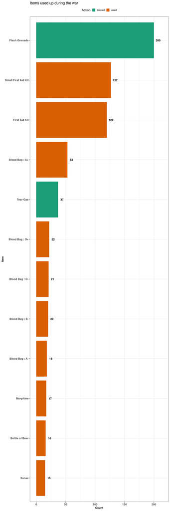

### Activity

Member activity during the war in hours.

```
## [1] "Correlation between activity and contribution:"
```

```
## [1] 0.48
```

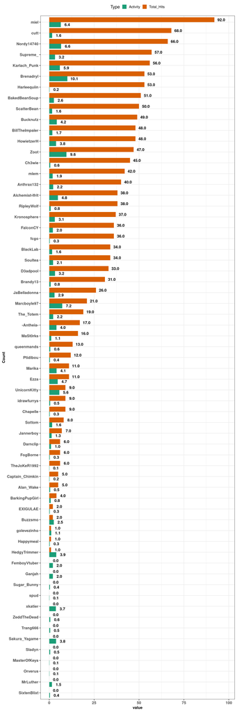

### Hospital

Summary of times hospitalized during the war

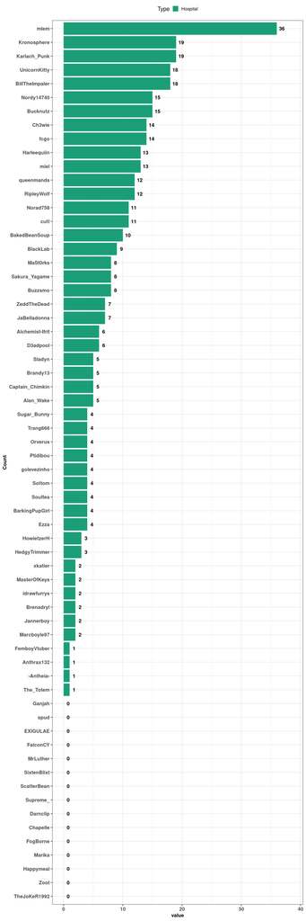

### Full table

|  | Name | War_Xanax | Refills | Boosters | Cans | Drug_cost | Booster_cost | Activity | Hospital |
| --- | --- | --- | --- | --- | --- | --- | --- | --- | --- |
| 1 | TheJoKeR1992 | 0 | 1 | 0 | 0 | 851175 | 0 | 0.12 | 0 |
| 2 | fcgo | 0 | 0 | 0 | 0 | 0 | 0 | 0.3 | 14 |
| 3 | HedgyTrimmer | 3 | 16 | 1 | 0 | 16273185 | 12327838 | 3.86 | 3 |
| 4 | Ezza | 5 | 1 | 0 | 0 | 5275150 | 0 | 4.71 | 4 |
| 5 | Zoot | 4 | 2 | 0 | 0 | 5241530 | 0 | 9.61 | 0 |
| 6 | The_Totem | 3 | 2 | 0 | 0 | 4356735 | 0 | 2.2 | 1 |
| 7 | Happymeal | 2 | 2 | 0 | 0 | 3471940 | 0 | 0.32 | 0 |
| 8 | Alan_Wake | 0 | 0 | 0 | 0 | 0 | 0 | 0.53 | 5 |
| 9 | Marika | 1 | 5 | 8 | 0 | 5140670 | 98622704 | 4.1 | 0 |
| 10 | BarkingPupGirl | 4 | 0 | 0 | 0 | 3539180 | 0 | 0.81 | 4 |

[output cut: 54 more lines]

## AI summary (BETA)

This is an experimental portion of the report - an overview of the war generated by AI.  
When looking at this section, keep that in mind and take the results with a grain of salt.  
Before taking any actions that might impact faction members mentioned in this summary, double-check that there are no mistakes or missed key details.

## 1) Overall Faction Performance

Overall, the faction showed **strong offensive output** with many members contributing meaningful war hits, and several players posting very solid positive Net_Score totals. The team had a good number of active participants, with a large share of members recording non-zero war hits and respectable activity levels.

The most positive signs were:

- **High participation** across the roster, with many members attacking rather than sitting idle.
- **Several strong contributors** who combined war hits, assists, and positive Net_Score effectively.
- **Generally acceptable efficiency**, with many members avoiding heavy E_Wasted totals.

At the same time, the faction’s performance was **uneven**. A noticeable number of members had:

- **No war hits**
- **No meaningful offensive contribution**
- **Negative Net_Score**
- **Low engagement relative to activity or level**

This suggests the faction had a solid core of active fighters, but could benefit from improved consistency and tighter target selection across the roster.

## 2) Areas for Improvement

- **Increase participation from zero-hit members.** Several members recorded no war hits or no real attacking contribution, which weakens overall faction pressure.
- **Reduce negative Net_Score entries.** A number of players ended the war in the negative, indicating inefficient or poorly timed attacks.
- **Improve target selection and attack efficiency.** Some members had higher E_Wasted, Lost, or Escape values than ideal.
- **Use activity more effectively.** A few members showed decent activity but very little combat output, suggesting missed opportunities.
- **Encourage more assists where war hits are low.** Assists are especially valuable when direct attacking volume is limited.

## 5) Additional Observations

- The faction had a **strong core** of high-output attackers, but a **significant tail of low-impact members** dragged down overall consistency.
- Several players with **high activity** still produced little or no war value, which suggests coordination or prioritization could be improved.
- The best performers combined:
  - **high war hits**
  - **positive Net_Score**
  - **useful assists**
  - **low waste**
- A few members stood out for having **good assist totals despite lower direct hit counts**, which is a positive sign of teamwork.